# Curso Intensivo de Introducción al lenguaje R

### Listas

Contienen una concatenación de objetos de cualquier tipo. Así como un vector contiene valores, un dataframe contiene vectores, una lista puede contener dataframes, pero también vectores, o valores, y *todo ello a la vez*

```r
LISTA <- list(A,B,C,D,E,Datos$AGLOMERADO, DF = Datos)
LISTA
```

```
[[1]]
[1] 1 2 2 2 1 1 1

[[2]]
[1] "Uno" "Dos" "Dos" "Dos" "Uno" "Uno" "Uno"

[[3]]
[1] 1 2 2 2 1 1 1
Levels: 1 2

[[4]]
[1] 3 5 6

[[5]]
[1] "4"     "Pablo" "9"

[[6]]
[1] 32 33 33 33 32

$DF
```

| AGLOMERADO | SEXO | EDAD |
| --- | --- | --- |
| 32 | Varon | 60 |
| 33 | Mujer | 54 |
| 33 | Mujer | 18 |
| 33 | Varon | 27 |
| 32 | Mujer | 32 |

```
NA
```

Tal como para con los Vectores y los Data.Frames, podemos acceder a un elemento de una lista, utilizando el operador **`$`**:

```r
LISTA$DF
```

| AGLOMERADO | SEXO | EDAD |
| --- | --- | --- |
| 32 | Varon | 60 |
| 33 | Mujer | 54 |
| 33 | Mujer | 18 |
| 33 | Varon | 27 |
| 32 | Mujer | 32 |

```r
LISTA$DF$EDAD
```

```
[1] 60 54 18 27 32
```

```r
LISTA$DF$EDAD[2]
```

```
[1] 54
```

También se pueden usar corchetes dobles **`[[]]`** para acceder a los distintos elementos de una lista.

```r
LISTA[[6]]
```

```
[1] 32 33 33 33 32
```

O para acceder a un valor/vector (dependiendo del tipo de elemento de la lista) de un objeto de la lista:

```r
LISTA[[6]][1]
```

```
[1] 32
```

```r
LISTA[[7]][2]
```

| SEXO |
| --- |
| Varon |
| Mujer |
| Mujer |
| Varon |
| Mujer |

```r
LISTA[[7]][2,1]
```

```
[1] 33
```

## Funciones:

Las funciones son series de procedimientos estandarizados, que toman como input determinados argumentos a fijar por el usuario (llamados parámetros), y devuelven un resultado acorde a la aplicación de dichos procedimientos. Su lógica de funcionamiento es:  
`funcion(argumento1 = arg1, argumento2 = arg2)`

A lo largo del curso iremos viendo numerosas funciones, según lo requieran los distintos ejercicios. Sin embargo, veamos ahora algunos ejemplos para comprender su funcionamiento:

- paste() : concatena una serie de caracteres, indicando por última instancia como separar a cada uno de ellos
- paste0(): concatena una serie de caracteres sin separar
- sum(): suma de todos los elementos de un vector
- mean() promedio aritmético de todos los elementos de un vector

```r
paste("Pega","estas", 4, "palabras", sep = " ")
```

```
[1] "Pega estas 4 palabras"
```

```r
#Puedo concatenar caracteres almacenados en objetos
a <- c(1, 2, 3)
b <- "con"
c <- c(4, 5, 6)

paste(a,b,c,sep = "-")
```

```
[1] "1-con-4" "2-con-5" "3-con-6"
```

```r
# Paste0 pega los caracteres sin separador
paste0(a,b,c)
```

```
[1] "1con4" "2con5" "3con6"
```

```r
# ¿Te acordás del comando que usamos?
1:5
```

```
[1] 1 2 3 4 5
```

```r
# Función para sumar
sum(1:5)
```

```
[1] 15
```

```r
# Para calclar medias
mean(1:5)
```

```
[1] 3
```

# Instalación de paquetes complementarios al R Base

Hasta aquí hemos visto múltiples funciones que están contenidas dentro del lenguaje básico de R. Ahora bien, al tratarse de un software libre, distintos usuarios de R contribuyen sistemáticamente a expandir este lenguaje mediante la creación y actualización de **paquetes** complementarios. Lógicamente, los mismos no están incluidos en la instalación inicial del programa, pero podemos descargarlos e instalarlos con el siguiente comando:

```
install.packages("nombre_del_paquete")
```

Los paquetes sólo se instalan una vez en la computadora (si cambias de computadora, tenés que volver a instalarlo). Una vez instalado el paquete, cada vez que abramos una nueva sesión de R y querramos utilizar el mismo debemos **cargarlo al ambiente de trabajo** mediante la siguiente función:

```
library(nombre_del_paquete)
```

Nótese que al cargar/activar el paquete no son necesarias las comillas.

# Lectura y escritura de archivos

A la hora de importar una base de datos nos podemos llegar a enfrentar a distintos tipos de archivos. En R contamos con **distintos paquetes y funciones** según el **tipo de extensión** del archivo:

| Tipo de archivo | Paquete | Extension | Funciones |
| --- | --- | --- | --- |
| Texto Plano | readr | .csv | read_csv() |
| Texto Plano | readr | .txt | read_txt() |
| Texto Plano | readr | .tsv | read_tsv() |
| Extension de R | RBase | .RDS | readRDS() |
| Extension de R | RBase | .RDATA | open() |
| Otros Softwares | haven | .dta | read_dta() |
| Otros Softwares | haven | .sav | read_spss() |
| Excel | openxlsx | .xlsx | read.xlsx() |
| Excel | readxl | .xls | read_excel() |

## Archivos de texto plano (csv, txt)

En archivos de texto plano, el paquete se recomienda usar el paquete **readr** (que forma parte de tidyverse). Las diferencias entre cada una de sus funciones está en los parámetros que poseen para mejorar la importación.

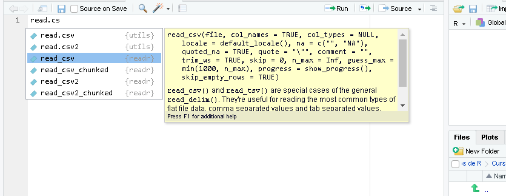

Es importante tener en cuenta que una base de datos que proviene de archivos *.txt*, o *.csv* puede presentar diferencias en cuanto a los siguientes parametros:

¿Qué es lo que indican algunos de los parámetros que tenemos en la imagen?

- encabezado (¿Tiene o no una primera fila con los nombes de las variables?)
- delimitador (¿Cómo están separadas las variables en el archivo?: Ej: `,`, `;`, tab)
- separador decimal (¿Cómo figuran los números en la base? Ej: ¿10.000, 10000 o 10,000)
- quotes: ¿Como están indicados los valores de las variables de texto en la base?, ¿Aparecen entre comillas?

Un ejemplo de cómo importar un archivo de tipo *delimitado por comas*

```
dataframe <- read.delim(file, header = TRUE, sep = ",", quote = "\"", dec = ".", fill = TRUE, comment.char = "", ...)
```

Vamos con una base de la EPH (base individual - 1er trimestre 2017)

En el parametro `file` tengo que especificar el nombre completo del archivo, incluyendo el directorio donde se encuentra. Lo más sencillo es abrir comillas, apretar `Tab` y se despliega el menú de las cosas que tenemos en el directorio de trabajo. Si queremos movernos hacia arriba en el directorio, agregamos `../`

```r
individual_t117 <- read.table(file = '../Fuentes/usu_individual_t117.txt',
                              sep=";",
                              dec=",",
                              header = TRUE,
                              fill = TRUE)
```

[output not shown]

[output cut: 990 more lines]

Como puede observarse desde el ambiente (environment), la base de la EPH cuentan con más de 58.000 registros y 177 variables. Al trabajar con bases de microdatos, resulta conveniente contar con algunos comandos para tener una mirada rápida de la base, antes de comenzar a realizar los procesamientos que deseemos.

Veamos algunos de ellos:

```r
#View(individual_t117) # Abre la base en una ventana aparte

names(individual_t117)[1:10] # Devuelve el nombre de  las variables. Le pido solo los primeros 10
```

```
 [1] "CODUSU"     "ANO4"       "TRIMESTRE"  "NRO_HOGAR"  "COMPONENTE" "H15"
 [7] "REGION"     "MAS_500"    "AGLOMERADO" "PONDERA"
```

```r
summary(individual_t117)[ ,c(8,10,31,133)] # Devuelve algunas medidas de resumen. Le pido ciertas columnas
```

```
   MAS_500             PONDERA           IMPUTA              P21
 Length:58675       Min.   :  25.0   Min.   :0.000000   Min.   :    -9
 Class :character   1st Qu.: 137.0   1st Qu.:0.000000   1st Qu.:     0
 Mode  :character   Median : 238.0   Median :0.000000   Median :     0
                    Mean   : 467.3   Mean   :0.002727   Mean   :  3671
                    3rd Qu.: 541.0   3rd Qu.:0.000000   3rd Qu.:  4800
                    Max.   :7001.0   Max.   :1.000000   Max.   :300000
```

```r
head(individual_t117)[ ,1:5] # Devuelve sólo los primeros valores para las columnas seleccionadas
```

|  | CODUSU | ANO4 | TRIMESTRE | NRO_HOGAR | COMPONENTE |
| --- | --- | --- | --- | --- | --- |
| 1 | TQRMNOQURHKOMLCDEFIAH00469284 | 2017 | 1 | 1 | 4 |
| 2 | TQRMNOQURHKOMLCDEFIAH00469284 | 2017 | 1 | 1 | 5 |
| 3 | TQRMNOQURHKOMLCDEFIAH00469284 | 2017 | 1 | 1 | 6 |
| 4 | TQRMNOQURHKOMLCDEFIAH00469284 | 2017 | 1 | 1 | 7 |
| 5 | TQRMNOQURHKOMLCDEFIAH00469284 | 2017 | 1 | 1 | 8 |
| 6 | TQRMNOQURHKOMLCDEFIAH00469284 | 2017 | 1 | 1 | 9 |

```r
unique(individual_t117$REGION)# Muestra los únicos valores que toma una variable
```

```
[1] 43 41 44 42 40  1
```

```r
# Notar que seguimos utilizando funciones de R base ya que no necesitamos cargar ningún 'paquete' para utilizarlos
```

## Excel

Para leer y escribir archivos excel debemos utilizar los comandos que vienen con la librería ´´´openxlsx´´´

# Directorio de trabajo

A la hora de trabajar con archivos que tenemos guardados (o queremos guardar) en nuestra computadora, es importante tener en cuenta que R siempre esta operando con un directorio de trabajo específico. Este directorio será el punto de partida para importar archivos al ambiente de R, o exportar objetos del ámbiente y guardarlos como archivos nuevos en nuestra PC

Con la función `getwd()` podemos visualizar la ruta que el programa tiene seteada como directorio de trabajo:

```r
getwd()
```

```
[1] "C:/Users/usuario/Desktop/Guido/Trabajo/Repositorios de R/Cursos de R/Intro_R_Intensivo/Modulo 1 - R Base"
```

Supongamos que quisieramos setear el directorio de trabajo en nuestra carpeta de “Fuentes”, con el fin de facilitar la importación de bases de datos. La función setwd() nos permite realizar esto.

```r
setwd("C:/Users/usuario/Desktop/Guido/Trabajo/Cursos Intro a R/Fuentes")
```

> ¿ Que problema tiene setear la ruta de trabajo de esta manera?

Cuando especifico de esta forma un directorio de trabajo en mi computadora para importar y exportar archivos:

- Si le comparto código y archivos a otra persona no podrá abrirlos.
- Si cambio de lugar la carpeta que contiene en mi computadora, tampoco podré abrir los archivos.

Rstudio tiene una herramienta muy útil de trabajo que son los **proyectos**.

[figure not shown]

Los proyectos permiten mantener un ambiente de trabajo delimitado por cada uno de nuestros trabajos. Es decir:

- El directorio de trabajo siempre toma como punto inicial la carpeta donde esta ubicada el archivo .Rproj
- El Environment es específico de nuestro proyecto. No se nos mezclará con resultados de código que podamos correr en otros proyecos.

Un proyecto no es un sólo script, sino toda una carpeta de trabajo.

Para crearlo, vamos al logo de nuevo projecto (Arriba a la derecha de la panatalla), y elegimos la carpeta de trabajo.

[figure not shown]

[figure not shown]

# Paquetes a utilizar a lo largo del curso:

Para quienes esten trabajando con sus computadoras personales, dejamos a continuación un listado de los paquetes complementarios del R base que utilizaremos a lo largo del curso. Como la instalación requiere descargar múltiples archivos de internet recomendamos hacerlo cuando dispongan de una buena conexión. Con el siguiente comando podrían instalarlos todos de una vez:

```
install.packages(c("tidyverse","openxlsx",'ggthemes',ggrepel','ggalt','kableExtra','stringr','lubridate','eph','esquisse','rmarkdown'))
```

[^1]: Más allá de los comandos elementales, comandos más sofisticados tienen muchas versiones, y algunas quedan en desuso en el tiempo.
[^2]: veremos que existen ciertas excepciones con algunos paquetes más adelante.